# Perceived Nurse-Physician Communication in Patient Care

#### Organizational Factors:

Perceived nurse-physician organizational factor sub scale generated through PCA and measured with five items: differential treatment of nurses or physician in the hospital, absence of forum regarding nurse-physician communication, lack of shared vision between nurses and physician in the hospital, malfunctioning of equipment in units, and frequent supply shortage in units. All of these factors measured with agreement Likert Scale and has minimum of 5 and maximum of 25. The higher the score indicates the more to be nurse-physician work attitude factor.

```r
org <- data.frame(data2[ ,28:32])
org_percent <- data.frame(data2,
                   rowsums_organizational = rowSums(org),
                   percent_organizational = ((rowSums(org)-5)/(25-5))*100)

org_final <- mutate(org_percent,
                     org_value = cut(percent_organizational,
                                          breaks = c(-1,60,80,101),
                                          labels = c("Low", "Moderate", "High"),
                                          right = FALSE))

org_prop <-prop.table(table(org_final$org_value))*100
org_prop
```

```
##
##      Low Moderate     High
##      100        0        0
```

```r
data2 <- data.frame(cbind(data2, org_final$rowsums_organizational, org_final$percent_organizational, org_final$org_value))

names(data2)[names(data2) == "org_final.rowsums_organizational"] <- "organizational_score"
names(data2)[names(data2) == "org_final.percent_organizational"] <- "organizational_percent"
names(data2)[names(data2) == "org_final.org_value"] <- "organization_value"
```

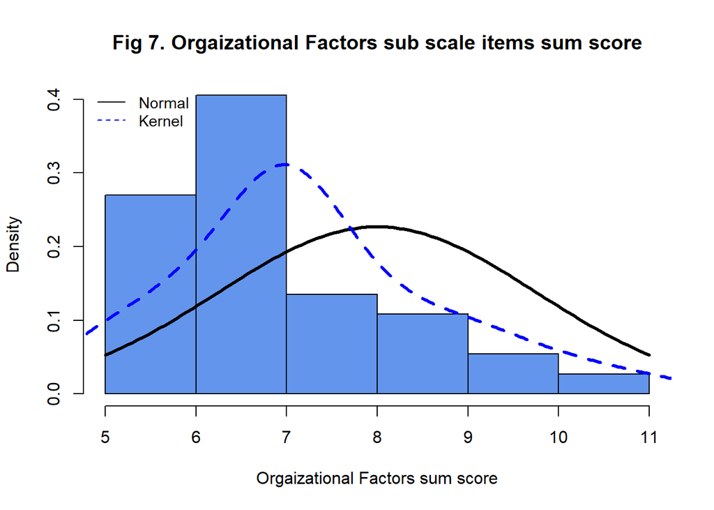

```r
hist (data2$organizational_score, col="cornflowerblue" , freq=FALSE,
      main="Fig 7. Orgaizational Factors sub scale items sum score",
xlab = "Orgaizational Factors sum score")
meanx <- mean(data2$organizational_score)
sdx <- sd (data2$organizational_score)
curve (dnorm(x , mean=mean(x) , sd=sd(x) ) ,
from=min(data2$organizational_score) , to=max(data2$organizational_score) , add=TRUE,
lty=1, col="Black " , lwd=3)
kernel <- density (data2$organizational_score)
points ( kernel$x  , kernel$y , type="l" ,
lty=2, col="blue " , lwd=3)
legend ("topleft" , c ("Normal " , "Kernel") , lty=c (1 ,2) ,
bty="n" , cex=.9 , col=c (" black " , " blue "))
```

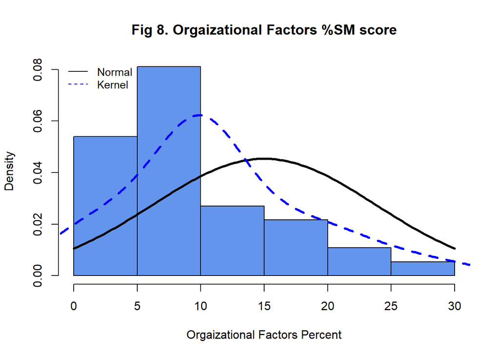

```r
hist (data2$organizational_percent, col="cornflowerblue" , freq=FALSE,
      main="Fig 8. Orgaizational Factors %SM score",
xlab = "Orgaizational Factors Percent")
meanx <- mean(data2$organizational_percent)
sdx <- sd (data2$organizational_percent)
curve (dnorm(x , mean=mean(x) , sd=sd(x) ) ,
from=min(data2$organizational_percent) , to=max(data2$organizational_percent) , add=TRUE,
lty=1, col="Black " , lwd=3)
kernel <- density (data2$organizational_percent)
points ( kernel$x  , kernel$y , type="l" ,
lty=2, col="blue " , lwd=3)
legend ("topleft" , c ("Normal " , "Kernel") , lty=c (1 ,2) ,
bty="n" , cex=.9 , col=c (" black " , " blue "))
```